# Lab Week 5

Drew Tyre

September 11, 2016

In this exercise we’ll practice fitting glms and making predictions. Download the data file [abundances.csv](https://my.unl.edu/bbcswebdav/users/atyre2/EcoStats/Module_2/GLM_week_5/Data/Abundances.csv?target=blank). This data set was collected by Andrea Hanson during her MSc. project in the School of Natural Resources. She sampled 14 transects in CRP fields scattered across SE Nebraska 4 times throughout the summer. She measured Visual Obstruction Readings (VOR) at 12 spots along each transect; these were averaged to obtain a single number representing vegetation structure within the CRP field. She also recorded the amount of 4 types of land use in the surrounding 2 km radius circle. These landscape metrics were highly correlated, so she used a Principle Components analysis to derive two combined metrics that were uncorrelated with each other. PC1 represents a gradient of increasing row crops, while PC2 represents decreasing woodland.

## Dickcissels

Begin your analysis of Dickcissels (column “DICK” in the data.frame) by plotting the response variable against all three covariates individually. Check for any signs of non-linearities.

```r
Abundances <- read.csv("data/Abundances.csv")
Abundances <- Abundances[,1:7] # drop bogus excel columns

library(tidyverse) # load all the things
```

```r
library(gridExtra) # to put multiple plots on one page

# make up a theme object that does what I want
my_theme <- theme_classic() +
  theme(text=element_text(size=rel(4)))

#some points overlap so use geom_count()
ggvor <- ggplot(Abundances, aes(x=vor, y=DICK)) +
  geom_count() + geom_smooth() +
  scale_size_area(max_size=4) +
  guides(size=FALSE) +
  my_theme
## OMG I just figured out how to make these plots
## with different x axis variables!!!
ggpc1 <- ggvor + aes(x = pc1)
ggpc2 <- ggvor + aes(x = pc2)
# geom_bar with stat="count" nice for discrete data
ggdick <- ggplot(Abundances, aes(x=DICK)) +
  geom_bar(stat="count") + my_theme
grid.arrange(ggvor, ggpc1, ggpc2, ggdick)
```

[output not shown]

Our response is *discrete*; only integer values occur. Moreover it is a count of events (seeing a bird), so no negative values occur. Both of these suggest that a Poisson distribution is a good choice.

So, we start by fitting a glm with a poisson error distribution using all three covariates and their pairwise interactions. Get the summary, and calculate the overall goodness of fit test to look for lack of fit. There aren’t many more models more complex than this for these data, so this will be our *global* model. We assess our assumptions with this model.

```r
library(broom)
dick.1 <- glm(DICK~(vor + pc1 + pc2)^2,data=Abundances,
              family=poisson)
sum.dick.1 <- glance(dick.1)
gof.p.dick.1 <- with(sum.dick.1,pchisq(deviance,df.residual,lower=FALSE))
```

So our model is significantly over-dispersed ($\chi^2=$ 88.06, df = 49, p = 0.0005217). That means that the estimated standard errors of our model are too small. For the moment we will ignore this issue, but keep in mind that tests of significance with this model are biased towards rejecting null hypotheses.

We can check the linearity assumption by plotting the deviance residuals against each covariate.

```r
dick.1.test <- augment(dick.1)
lin.vor <- ggplot(dick.1.test, aes(x = vor, y = .std.resid)) + geom_count() +
  scale_size_area(max_size=4) +
  geom_hline(yintercept = 0, linetype = 2) +
  geom_smooth() + guides(size = FALSE) +
  my_theme

lin.pc1 <- lin.vor + aes(x = pc1)
lin.pc2 <- lin.vor + aes(x = pc2)

grid.arrange(lin.vor, lin.pc1, lin.pc2)
```

[output not shown]

That’s a bit squashed, but the horizontal line is inside the confidence polygon of the smooth fit throughout, so there is no indication that the linearity assumption is violated.

Finally, examine the residual plots.

```r
resd1 <- ggplot(dick.1.test, aes(x = .fitted, y = .resid)) +
  geom_point() +
  geom_smooth() +
  geom_hline(yintercept = 0, linetype=2) +
  my_theme

resd2 <- resd1 + aes(y = sqrt(abs(.std.resid))) +
  geom_hline(yintercept = 1, linetype=2)

resd3 <- ggplot(dick.1.test, aes(.hat, .std.resid)) +
 geom_vline(size = 2, colour = "white", xintercept = 0) +
  geom_hline(size = 2, colour = "white", yintercept = 0) +
  geom_point(aes(size = .cooksd)) + geom_smooth(se = FALSE) +
  my_theme

# get int and slope for qqline
probs <- c(0.25,0.75)
y <- quantile(dick.1.test$.std.resid, probs, names = FALSE, na.rm = TRUE)
x <- qnorm(probs)
slope <- diff(y)/diff(x)
int <- y[1L] - slope * x[1L]

qq.dick <- ggplot(dick.1.test, aes(sample=.std.resid)) +
  geom_qq(size=rel(4)) +
  geom_abline(intercept = int, slope = slope, linetype = 2, size = 2) +
  my_theme

grid.arrange(resd1, resd2, resd3, qq.dick)
```

[output not shown]

Nothing particularly worrisome there. There are some particularly large negative residuals that are probably contributing to the overdispersion, but they don’t look too bad.

```r
models = list(DICK~1,DICK~vor,
              DICK~vor + pc1,
              DICK~vor + pc1 + vor:pc1,
              DICK~vor + pc2,
              DICK~vor + pc2 + vor:pc2,
              DICK~vor + pc1 + pc2,
              DICK~vor + pc1 + pc2 + vor:pc1,
              DICK~vor + pc1 + pc2 + vor:pc2,
              DICK~vor + pc1 + pc2 + vor:pc1 + vor:pc2,
              DICK~(vor + pc1 + pc2)^2)
fits = lapply(models,glm,data=Abundances,family="poisson")
```

We could calculate $\hat{c}$ manually, but package AICcmodavg has a function to do it for us, and we’ll use it to get a table of the Quasi-AICc values.

```r
library(AICcmodavg)
library(pander)
# get shorter model names (remove DICK ~)
modnames=sapply(models,function(ff)deparse(ff[[3]]))
pander(aictab(fits,c.hat=c_hat(fits[[11]]),modname=modnames), caption="Table 1. AICc model selection table for Dickcissel relative abundance in CRP fields.", split.tables=Inf)
```

[output not shown]

1. Which model or models do you think you should pay attention to and why?

The top model includes pc2 and it’s interaction with vor. In fact, the four top models all include those terms. The second through fourth ranked models are all within 2 likelihood units of the top model, suggesting that nesting is playing a role here. Thus it seems justifiable to simply use the top model as our model for prediction. However, model averaging the predictions is quite easy given the AICcmodavg package, so lets try both ways and see how much it matters. As before, create some new data assuming pc1 and pc2 are at the median values:

```r
nd = data.frame(vor=seq(2,9,0.1),
                pc1=median(Abundances$pc1),
                pc2=median(Abundances$pc2))
pred.dick = augment(fits[[6]], newdata = nd, type.predict="response")

pred.mavg = modavgPred(fits, newdata=nd, type="response",
                       c.hat=c_hat(fits[[11]]),modnames=modnames)

pred.dick$mod.avg.pred <- pred.mavg$mod.avg.pred
pred.dick$uncond.se <- pred.mavg$uncond.se

ggplot(Abundances, aes(x = vor, y = DICK)) +
  geom_count() +
  scale_size_area(max_size = 4) +
  geom_line(aes(y=.fitted), data=pred.dick, size=2) +
  geom_line(aes(y=mod.avg.pred), data=pred.dick, size=2, linetype = 2) +
  my_theme + guides(size=FALSE)
```

[output not shown]

So the model averaged prediction is right on top of the top model prediction in this case. Let’s look at the model coefficients for those top four models

```r
# poo. easy way with stargazer doesn't play with tidyverse
# make a dataframe
tidy_w_name <- function(.x, .y){
  df <- tidy(.x) #get the coefficient table
  df$modname <- .y #add a column with the modname
  df # return df
}
# just the top 4 models to save grief later
etc <- map2_df(fits[c(6,9,10,11)], modnames[c(6,9,10,11)], tidy_w_name)

etc <- mutate(etc, Estimate = paste(formatC(estimate,digits=3, format="f")," (", formatC(std.error,digits=3, format="f"),")", sep=""))
tab <- spread(etc[,c(1,6,7)], key=modname, value = Estimate )
# arrange the models in order ...
pander(tab[,5:2], split.tables=Inf, caption="Table 2. Estimates (SE) for each of the top four models.")
```

[output not shown]

The row ordering of that table isn’t the best, but it’ll work for now. What I want to do is check to see if any of the coefficients from the second through fourth ranked models have estimates more than 2 SE from zero. For example, `pc1` is at most 2 times the SE in those models. The value of the other two coefficients `pc1:pc2` and `vor:pc1` also have small magnitudes relative to their SE. This increases our confidence that nesting effects are responsible for the model selection uncertainty. Ignoring the model selection uncertainty might make our predictions a bit too precise, but the parameters `vor`, `pc2` and `vor:pc2` are very similar across the four models.

```r
nd = crossing(vor=seq(2,9,0.1),
              pc2=quantile(Abundances$pc2))
nd$pc2Labels <- factor(rep_len(c("Min","25%","50%","75%","Max"), nrow(nd)))
pred.dick = augment(fits[[6]], newdata = nd, type.predict="response")

ggplot(Abundances, aes(x = vor, y = DICK)) +
  geom_count() +
  scale_size_area(max_size = 4) +
  geom_line(aes(y=.fitted, colour=pc2Labels), data=pred.dick, size=2) +
  my_theme +
  guides(size=FALSE) +
  theme(legend.text=element_text(size=16))+
  scale_color_discrete(breaks=c("Min","25%","50%","75%","Max"), name="PC2") +
  scale_y_continuous(limits=c(0,25)) +
  xlab("Visual Obstruction Reading") +
  ylab("Dickcissel Abundance")
```

[output not shown]

I spent a long time fussing around to make that graph look like I wanted. The defaults are often nice but sometimes you want something specific. To see the “quick and dirty” starting point for that graph run the first 4 lines leaving out the final ‘+’.

2. Think carefully about the sign of the coefficients in the top model from Table 2. Does the direction of the trend in the graph match what you think the coefficients are telling you? (hint: the simple effect of pc2 is when vor = 0)

# Incidence function model

Note: If you’re working ahead I haven’t modified this section to use ggplot and the tidyverse yet.

Working with binary data is similar, but back-transforming the link function is a bit more involved. Also the global goodness of fit test doesn’t work when the data are zero/one. Download the file [isolation.txt](https://my.unl.edu/bbcswebdav/users/atyre2/EcoStats/Module_2/GLM_week_5/Data/isolation.txt?target=blank), which has three variables, incidence (presence/absence of a species), area of island (km^2), and isolation (distance to mainland in km). This exercise is modified from pg. 595 of Michael Crawley’s “The R Book”.

```r
island <- read.table("data/isolation.txt",header=TRUE)
names(island)
```

```
## [1] "incidence" "area"      "isolation"
```

Plot the area using boxplots for present and absent. *Thought provoker - Do you expect there to be effects of area and isolation, and in which direction should they go?* Next we’ll fit a binomial GLM, and then simplify using backwards selection.

```r
island.1 = glm(incidence~area * isolation, data=island,family=binomial)
island.2 = glm(incidence~area + isolation, data=island,family=binomial)
anova(island.2,island.1,test="Chisq")
```

```
## Analysis of Deviance Table
##
## Model 1: incidence ~ area + isolation
## Model 2: incidence ~ area * isolation
##   Resid. Df Resid. Dev Df Deviance Pr(>Chi)
## 1        47     28.402
## 2        46     28.252  1  0.15043   0.6981
```

So the simpler model is not worse than the more complex model. Check the summary to find the weakest single term, and continue with the backwards selection.

```r
summary(island.2)
```

```
##
## Call:
## glm(formula = incidence ~ area + isolation, family = binomial,
##     data = island)
##
## Deviance Residuals:
##     Min       1Q   Median       3Q      Max
## -1.8189  -0.3089   0.0490   0.3635   2.1192
##
## Coefficients:
##             Estimate Std. Error z value Pr(>|z|)
## (Intercept)   6.6417     2.9218   2.273  0.02302 *
## area          0.5807     0.2478   2.344  0.01909 *
## isolation    -1.3719     0.4769  -2.877  0.00401 **
## ---
## Signif. codes:  0 '***' 0.001 '**' 0.01 '*' 0.05 '.' 0.1 ' ' 1
##
## (Dispersion parameter for binomial family taken to be 1)
##
##     Null deviance: 68.029  on 49  degrees of freedom
## Residual deviance: 28.402  on 47  degrees of freedom
## AIC: 34.402
##
## Number of Fisher Scoring iterations: 6
```

```r
# area has the smallest z score
island.3 = update(island.2,.~.-area)
anova(island.3,island.2,test="Chisq")
```

```
## Analysis of Deviance Table
##
## Model 1: incidence ~ isolation
## Model 2: incidence ~ area + isolation
##   Resid. Df Resid. Dev Df Deviance Pr(>Chi)
## 1        48     36.640
## 2        47     28.402  1   8.2375 0.004103 **
## ---
## Signif. codes:  0 '***' 0.001 '**' 0.01 '*' 0.05 '.' 0.1 ' ' 1
```

So removing `area` does make a significant difference, so we stop with `island.2`. *Thought provoker - Does the sign of the coefficients for area and isolation match your expectations from the boxplots?* *Though provoker - Have a look at the plots of the residuals - do they look good to you?* Next we want to plot the effects.

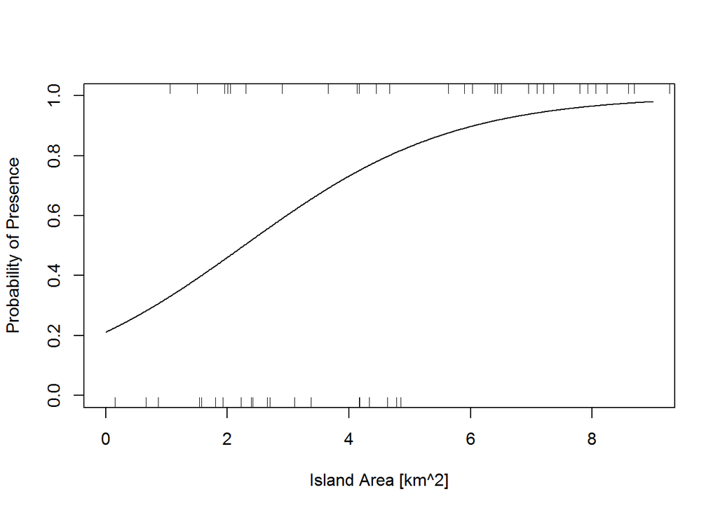

```r
nd = data.frame(area=seq(0,9,0.01),isolation=median(island$isolation))
pred.p = predict(island.2,newdata=nd,type="response")
plot(nd$area,pred.p,type="l",ylim=c(0,1),xlab="Island Area [km^2]",ylab="Probability of Presence")
rug(island[island$incidence==0,"area"])
rug(island[island$incidence==1,"area"],side=3)
```

The “rug plots” are a way to show where the data points are located along the x-axis without cluttering up the graph too much. *Thought provoker - can you find another way to get a vector of island areas when incidence == 0?* Make a plot of the effect of isolation on incidence when island area is held at the median value.

Adding confidence limits to this sort of plot requires making the prediction on the linear predictor scale, constructing the confidence limits, and then back-transforming the predictions to the response scale using the inverse link function. There are several ways to write the inverse link function for a logit link model, but the easiest to use in my opinion is
$$\hat{p} = \frac{1}{1+e^{-\beta X}}$$
where $\beta X$ is the prediction on the link scale.

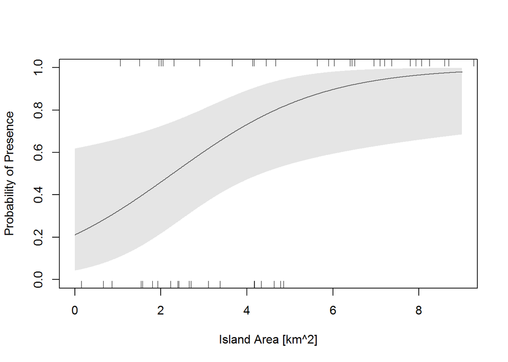

```r
nd = data.frame(area=seq(0,9,0.01),isolation=median(island$isolation))
pred.p = predict(island.2,newdata=nd,type="link",se.fit=TRUE)
plot(nd$area,1/(1+exp(-pred.p$fit)),type="l",ylim=c(0,1),
     xlab="Island Area [km^2]",ylab="Probability of Presence")
rug(island[island$incidence==0,"area"])
rug(island[island$incidence==1,"area"],side=3)
lo.95 = pred.p$fit - 2*pred.p$se.fit
up.95 = pred.p$fit + 2*pred.p$se.fit
polygon(c(nd$area,rev(nd$area)),1/(1+exp(-c(lo.95,rev(up.95)))),
        col=rgb(0.8,0.8,0.8,0.5),border=NA)
```

Go back and make a new plot for the effect of isolation that includes the 95% confidence region.

What would happen if we used AIC model selection on this dataset?

```r
models = list(incidence~1,
              incidence~area,
              incidence~isolation,
              incidence~area + isolation,
              incidence~area + isolation + area:isolation)
fits = lapply(models,glm,family=binomial,data=island)
aictab(fits,as.character(models))
```

```
##
## Model selection based on AICc :
##
##                                               K  AICc Delta_AICc AICcWt
## incidence ~ area + isolation                  3 34.92       0.00   0.72
## incidence ~ area + isolation + area:isolation 4 37.14       2.22   0.24
## incidence ~ isolation                         2 40.90       5.97   0.04
## incidence ~ area                              2 54.43      19.50   0.00
## incidence ~ 1                                 1 70.11      35.19   0.00
##                                               Cum.Wt     LL
## incidence ~ area + isolation                    0.72 -14.20
## incidence ~ area + isolation + area:isolation   0.96 -14.13
## incidence ~ isolation                           1.00 -18.32
## incidence ~ area                                1.00 -25.09
## incidence ~ 1                                   1.00 -34.01
```